# Modeling and prediction for movies

## Setup

### Load packages

```r
library(tidyverse)
library(statsr)
library(GGally)
library(RColorBrewer)

theme_set(theme_classic())
```

### Load data

```r
load("movies.Rdata")
```

## Introduction

The background context regarding the assignment can be found at:  
https://www.coursera.org/learn/linear-regression-model/supplement/UQWxR/project-instructions-data-files-and-checklist

## About the dataset

The data set is comprised of 651 randomly sampled movies produced and released before 2016, including information from Rotten Tomatoes and IMDB.

Therefore, studies based on this sample are:

- generalizable to the movie released before 2016;
- not causal, since no random assignment is used in sample collecting.

## Research question

Is there a relationship between critics’ scores and the audience score of a movie on Rotten Tomatoes? Moreover, how well could we predict a movie’s audience score using its critics’ score along with some other variable?

Motivation: movies are often said to be overrated or underrated by professional critics, if so, how much do the critics and audience disagree with each other?

## Exploratory data analysis

### Relationship between critics and audience score

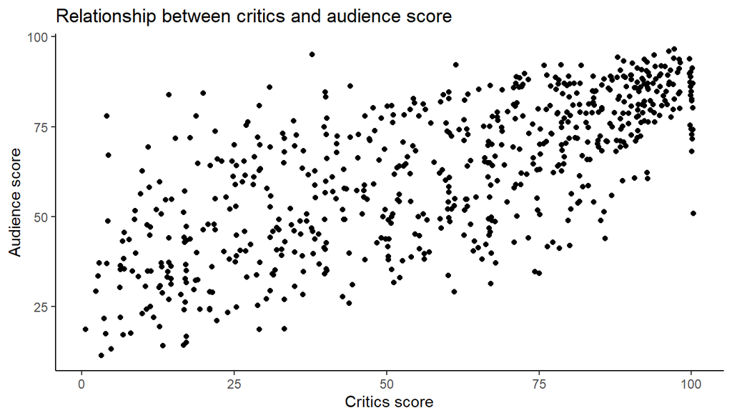

```r
movies %>%
  ggplot(aes(critics_score, audience_score)) +
  geom_jitter() +
  labs(
    x = "Critics score",
    y = "Audience score",
    title = "Relationship between critics and audience score"
  )
```

```r
cor(movies$critics_score, movies$audience_score)
```

```
## [1] 0.7042762
```

There appears to be a positive correlation between critics’ scores and audience scores.

Before building the linear regression model, lets us find out other variables that can contribute to the audience score.

### Audience score by genre

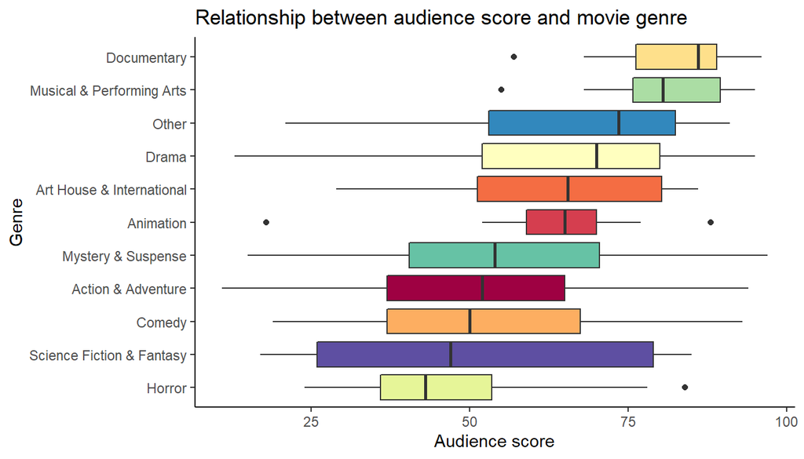

```r
movies %>%
  group_by(genre) %>%
  mutate(mean = mean(audience_score)) %>%
  ggplot(aes(fct_reorder(genre, mean), audience_score, fill = genre)) +
  geom_boxplot() +
  coord_flip() +
  labs(
    x = "Genre",
    y = "Audience score",
    title = "Relationship between audience score and movie genre"
  ) +
  scale_fill_brewer(palette = "Spectral") +
  theme(
    legend.position = "none"
  )
```

It seems like different genres of movies do have different distributions of audience scores. The `Documentary` genre has the highest mean audience score compared to the other movie genres; the `Science Fiction & Fantasy` genre has the biggest spread of audience score.

### Audience score by MPAA rating

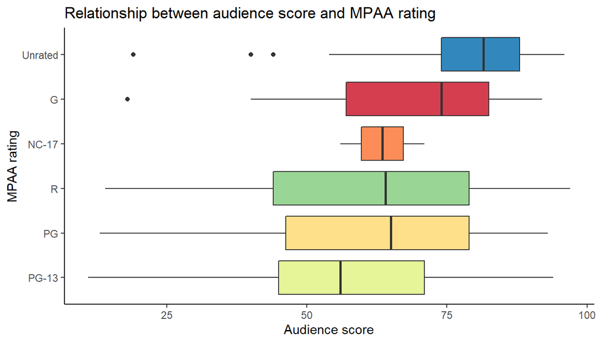

```r
movies %>%
  group_by(mpaa_rating) %>%
  mutate(mean = mean(audience_score)) %>%
  ggplot(aes(fct_reorder(mpaa_rating, mean), audience_score, fill = mpaa_rating)) +
  geom_boxplot() +
  coord_flip() +
  labs(
    x = "MPAA rating",
    y = "Audience score",
    title = "Relationship between audience score and MPAA rating"
  ) +
  scale_fill_brewer(palette = "Spectral") +
  theme(
    legend.position = "none"
  )
```

The MPAA rating also seems to influence the audience score.

### Audience score by best picture Oscar nomination

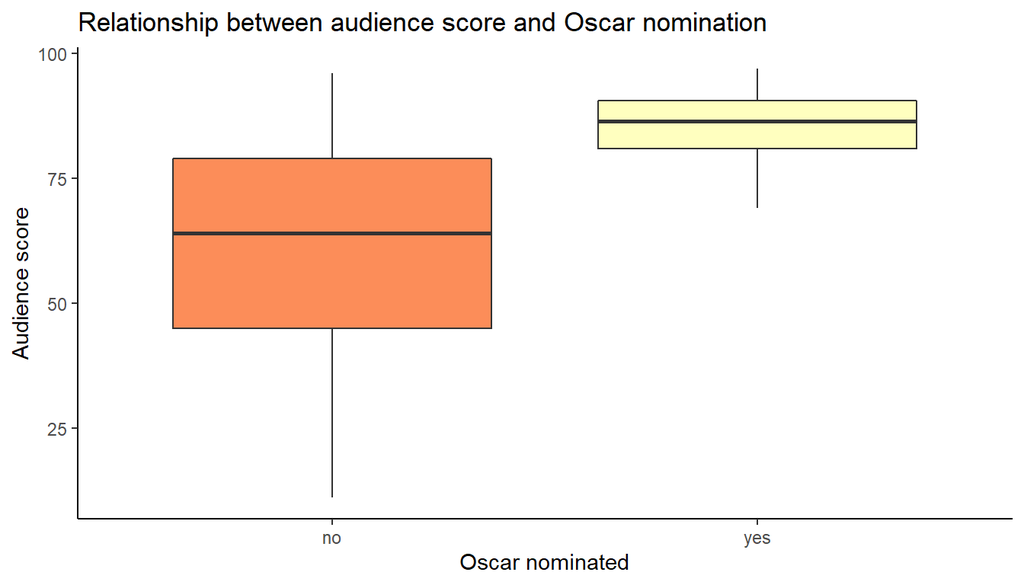

```r
movies %>%
  ggplot(aes(best_pic_nom, audience_score, fill = best_pic_nom)) +
  geom_boxplot() +
  labs(
    x = "Oscar nominated",
    y = "Audience score",
    title = "Relationship between audience score and Oscar nomination"
  ) +
  scale_fill_brewer(palette = "Spectral") +
  theme(
    legend.position = "none"
  )
```

The movies nominated for best picture Oscar receive higher audience scores.

### Relationship between IMDB rating and audience score

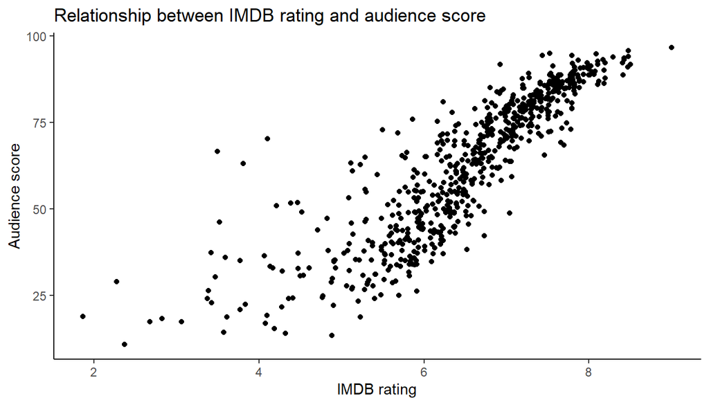

```r
movies %>%
  ggplot(aes(imdb_rating, audience_score)) +
  geom_jitter() +
  labs(
    x = "IMDB rating",
    y = "Audience score",
    title = "Relationship between IMDB rating and audience score"
  )
```

```r
cor(movies$imdb_rating, movies$audience_score)
```

```
## [1] 0.8648652
```

## Part 4: Modeling

```r
movies_df <-
  movies %>%
  select(genre, mpaa_rating, imdb_rating, critics_score, audience_score, best_pic_nom)
```

The create the model, we need to subset the dataset into useful predictors only.

```r
# define intercept-only model
intercept_only <- lm(audience_score ~ 1, data = movies_df)

# define model with all predictors
fullmodel <- lm(audience_score ~ ., data = movies_df)

# perform backward stepwise regression
backward <- step(fullmodel, direction = "backward", scope = formula(fullmodel), trace = 0)

# view results of backward stepwise regression
backward$anova
```

```
##             Step Df Deviance Resid. Df Resid. Dev      AIC
## 1                NA       NA       632   61134.04 2995.047
## 2  - mpaa_rating  5 178.8183       637   61312.86 2986.948
## 3 - best_pic_nom  1 176.0006       638   61488.86 2986.814
```

```r
# view final model
backward$coefficients
```

```
##                    (Intercept)                 genreAnimation
##                   -37.15275404                     9.11697560
## genreArt House & International                    genreComedy
##                     0.03008086                     2.09166972
##               genreDocumentary                     genreDrama
##                     1.19414230                    -0.20316071
##                    genreHorror genreMusical & Performing Arts
##                    -5.02794886                     4.39790898
##        genreMystery & Suspense                     genreOther
##                    -6.25278984                     1.58227779
## genreScience Fiction & Fantasy                    imdb_rating
##                    -0.29079052                    14.76643828
##                  critics_score
##                     0.06686755
```

Here is how to interpret the results:

- We fit a model using all p predictors. Define this as $M_p$.
- For k = p, p-1, … 1, we fit all k models that contain all but one of the predictors in $M_k$, for a total of k-1 predictor variables. Next, pick the best among these k models and call it $M_{k-1}$.
- We pick a single best model from among $M_0…M_p$ using AIC.

The final model turns out to be:

```r
model <- lm(audience_score ~ . - mpaa_rating - best_pic_nom, data = movies_df)

summary(model)
```

```
##
## Call:
## lm(formula = audience_score ~ . - mpaa_rating - best_pic_nom,
##     data = movies_df)
##
## Residuals:
##     Min      1Q  Median      3Q     Max
## -26.708  -6.446   0.614   5.479  50.111
##
## Coefficients:
##                                 Estimate Std. Error t value Pr(>|t|)
## (Intercept)                    -37.15275    3.10900 -11.950  < 2e-16 ***
## genreAnimation                   9.11698    3.49847   2.606 0.009375 **
## genreArt House & International   0.03008    2.90452   0.010 0.991740
## genreComedy                      2.09167    1.61412   1.296 0.195493
## genreDocumentary                 1.19414    1.96833   0.607 0.544281
## genreDrama                      -0.20316    1.38018  -0.147 0.883022
## genreHorror                     -5.02795    2.38740  -2.106 0.035591 *
## genreMusical & Performing Arts   4.39791    3.13828   1.401 0.161588
## genreMystery & Suspense         -6.25279    1.77914  -3.515 0.000472 ***
## genreOther                       1.58228    2.76266   0.573 0.567024
## genreScience Fiction & Fantasy  -0.29079    3.50319  -0.083 0.933872
## imdb_rating                     14.76644    0.57286  25.777  < 2e-16 ***
## critics_score                    0.06687    0.02142   3.122 0.001879 **
## ---
## Signif. codes:  0 '***' 0.001 '**' 0.01 '*' 0.05 '.' 0.1 ' ' 1
##
## Residual standard error: 9.817 on 638 degrees of freedom
## Multiple R-squared:  0.7687, Adjusted R-squared:  0.7643
## F-statistic: 176.7 on 12 and 638 DF,  p-value: < 2.2e-16
```

### Model Diagnostic

Before making predictions, we would like to check if our model satisfies all the conditions for a multiple linear regression model.

1. Linearity We are going to create a scatterplot of the model residuals versus the numerical explanatory variables, `imdb_rating` and `critics_score`.

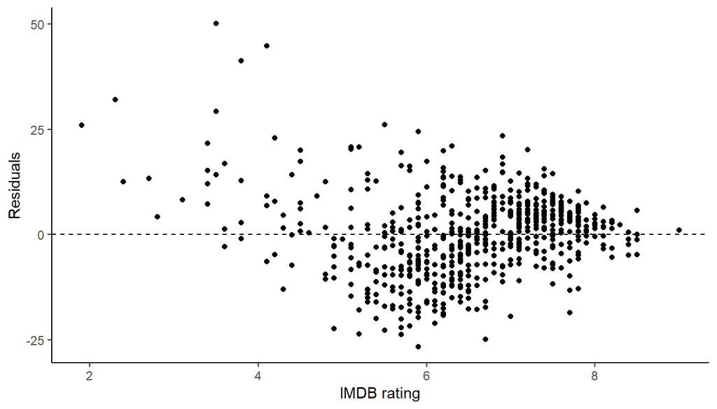

```r
imdb_residual <- data.frame(residuals = model$residuals, imdb_rating = movies$imdb_rating)
critic_residual <- data.frame(residuals = model$residuals, critics_score = movies$critics_score)

ggplot(imdb_residual, aes(imdb_rating, residuals)) +
  geom_point() +
  geom_hline(yintercept = 0, linetype = "dashed") +
  labs(
    x = "IMDB rating",
    y = "Residuals")
```

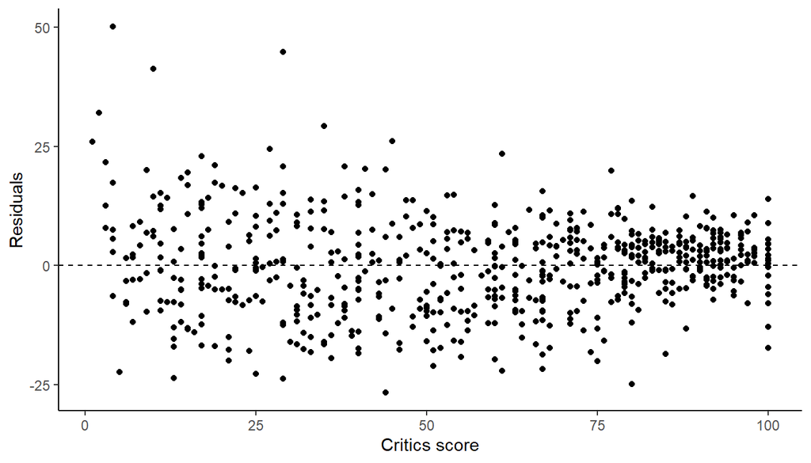

```r
ggplot(critic_residual, aes(critics_score, residuals)) +
  geom_point() +
  geom_hline(yintercept = 0, linetype = "dashed") +
  labs(
    x = "Critics score",
    y = "Residuals")
```

2. Nearly normal residual

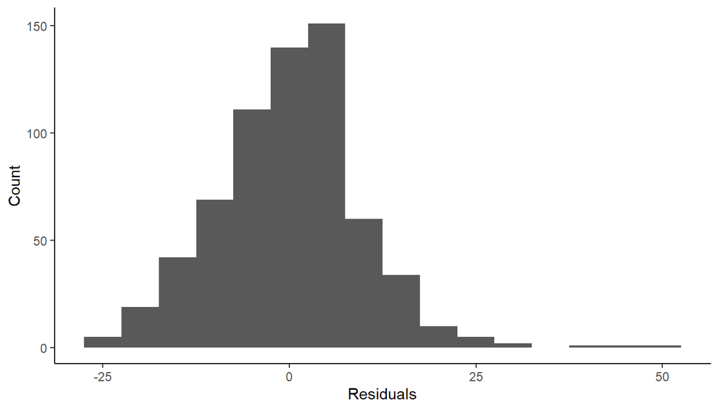

```r
ggplot(data = model, aes(x = .resid)) +
  geom_histogram(binwidth = 5) +
  labs(x = "Residuals", y = "Count")
```

The model residuals seems normally distributed around 0, which means that this condition is satisfied as well.

## Prediction

We can now use the model to predict the audience score for new movies (movies released after 2016). For this task, we are going to predict the audience score of `Bullet Train(2022)`, `The Social Dilemma(2020)`, `Tenet`(2020), `The Call`(2020), and `Spenser Confidential`(2020). The real audience score of those movies is 76, 83, 76, 78, and 51 respectively.

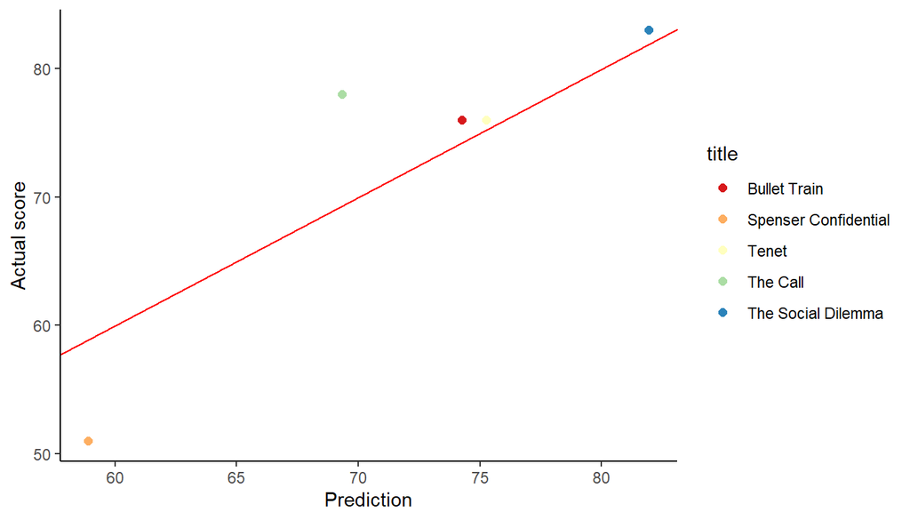

```r
new_movies <- data.frame(
  genre = c("Action & Adventure", "Documentary", "Action & Adventure", "Horror", "Comedy"),
  mpaa_rating = c("R", "PG-13", "PG-13", "R", "R"),
  critics_score = c(54, 85, 69, 100, 36),
  imdb_rating = c(7.3, 7.6, 7.3, 7.1, 6.2),
  best_pic_nom = c("no", "no", "no", "no", "no")
)

real_score <- c(76, 83, 76, 78, 51)

prediction <- as.data.frame(predict(model, new_movies, interval = "prediction", level = 0.95))

prediction$score <- real_score

prediction$title <- c("Bullet Train", "The Social Dilemma", "Tenet", "The Call", "Spenser Confidential")

prediction %>%
  ggplot(aes(fit, score, color = title)) +
  geom_point(size = 2) +
  geom_abline(intercept = 0,
              slope = 1,
              color = "red") +
  labs(
    x = "Prediction",
    y = "Actual score"
  ) +
  scale_color_brewer(palette = "Spectral")
```

```r
rsq <- function (x, y) cor(x, y) ^ 2

rsq(prediction$fit, prediction$score)
```

```
## [1] 0.831216
```